# U.S. Gasoline Prices Prediction

Gorbunov Sergey, 416

Подключаем необходимые библиотеки.

```r
library(readxl)
library(tseries)
library(forecast)
library(TSA)
library(fitdistrplus)
library(zoo)
library(car)
library(nortest)
```

Отберем данные с начала января 2010 года по конец 2014 года.

```r
data <- read_xls('PET_PRI_GND_DCUS_NUS_W.xls', sheet = 'Data 1', range = 'A3:B1625')
data <- data.frame(Date = data[[1]], Gasoline_Prices = data[[2]])
data <- na.omit(data)
data <- data[data$Date >= '2010-01-04' & data$Date <= '2015-01-05', ]
head(data)
```

```
##            Date Gasoline_Prices
## 1012 2010-01-04           2.718
## 1013 2010-01-11           2.804
## 1014 2010-01-18           2.793
## 1015 2010-01-25           2.760
## 1016 2010-02-01           2.717
## 1017 2010-02-08           2.707
```

```r
tail(data)
```

```
##            Date Gasoline_Prices
## 1267 2014-11-24           2.907
## 1268 2014-12-01           2.864
## 1269 2014-12-08           2.767
## 1270 2014-12-15           2.643
## 1271 2014-12-22           2.496
## 1272 2014-12-29           2.392
```

Создадим временной ряд и исследуем его на стационарность.

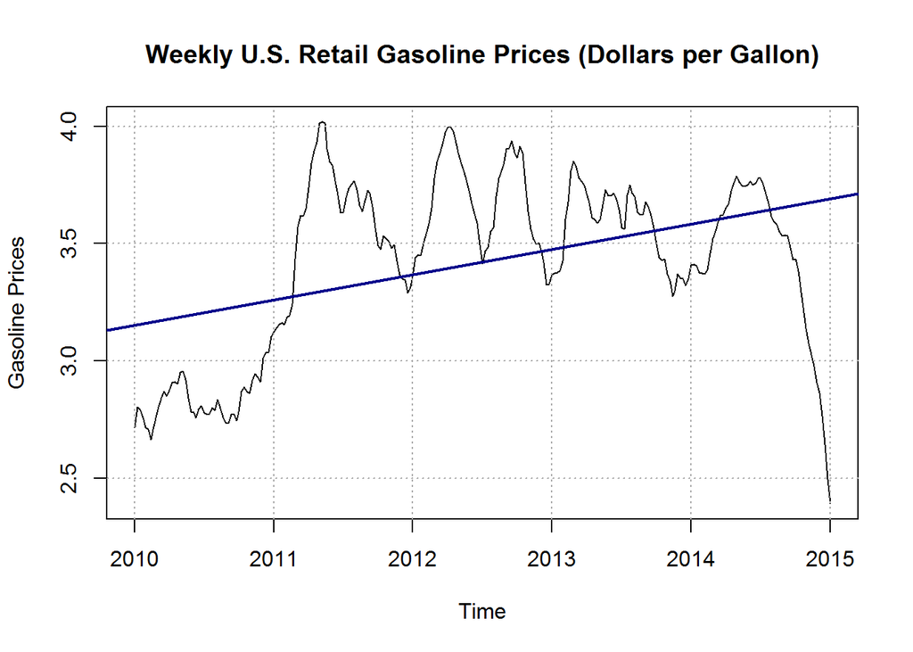

```r
ts <- ts(data$Gasoline_Prices, start = c(2010, 1), frequency = 52)
plot(ts, ylab = 'Gasoline Prices',
     main = 'Weekly U.S. Retail Gasoline Prices (Dollars per Gallon)')
abline(v = (seq(2010, 2015, by = 1)), col = 'darkgray', lty = 'dotted')
abline(h = (seq(2.5, 4, by = 0.5)), col = 'darkgray', lty = 'dotted')
abline(reg = lm(ts ~ time(ts)), col = 'darkblue', lw = 2)
```

Судя по графику, предполагаем нестационарность ряда. Проведем расширенный тест Дики-Фуллера.

```r
adf.test(ts)
```

```
##
##  Augmented Dickey-Fuller Test
##
## data:  ts
## Dickey-Fuller = -1.2639, Lag order = 6, p-value = 0.8859
## alternative hypothesis: stationary
```

Гипотеза о нестационарности исходного ряда не отвергается. Построим ряд приращений исходного ряда.

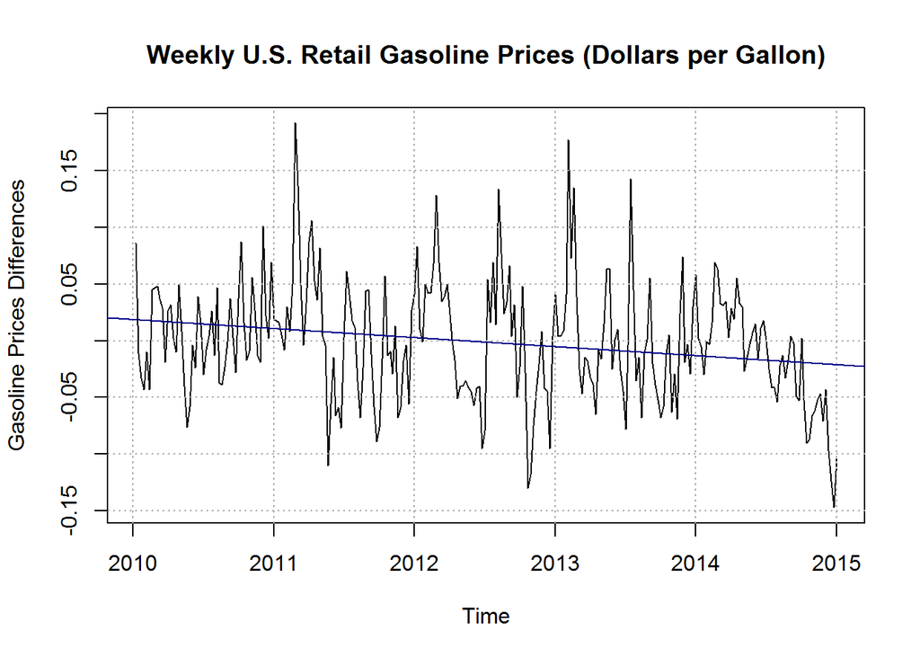

```r
dts <- diff(ts)
plot(dts, ylab = 'Gasoline Prices Differences',
     main = 'Weekly U.S. Retail Gasoline Prices (Dollars per Gallon)')
abline(v = (seq(2010, 2015, by = 1)), col = 'darkgray', lty = 'dotted')
abline(h = (seq(-0.15, 0.15, by = 0.05)), col = 'darkgray', lty = 'dotted')
abline(reg = lm(dts ~ time(dts)), col = 'darkblue')
```

```r
adf.test(dts)
```

```
##
##  Augmented Dickey-Fuller Test
##
## data:  dts
## Dickey-Fuller = -4.3526, Lag order = 6, p-value = 0.01
## alternative hypothesis: stationary
```

Гипотеза о нестационарности ряда приращений отвергается.

Исследуем ACF и PACF ряда приращений.

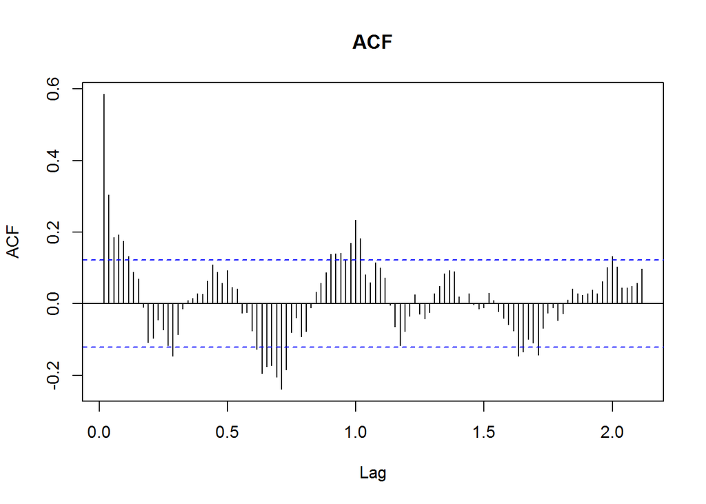

```r
acf(dts, lag.max = 110, main = 'ACF')
```

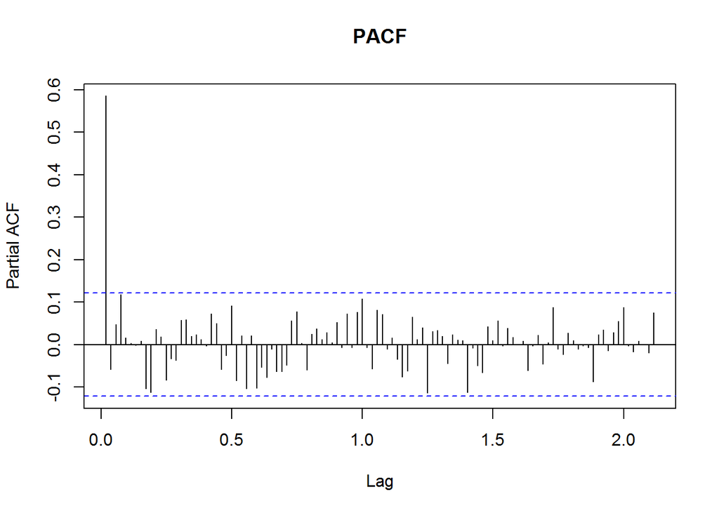

```r
pacf(dts, lag.max = 110, main = 'PACF')
```

Более выразительным является график PACF, рассмотрим его в окрестности нуля для определения несезонной составляющей AR модели.

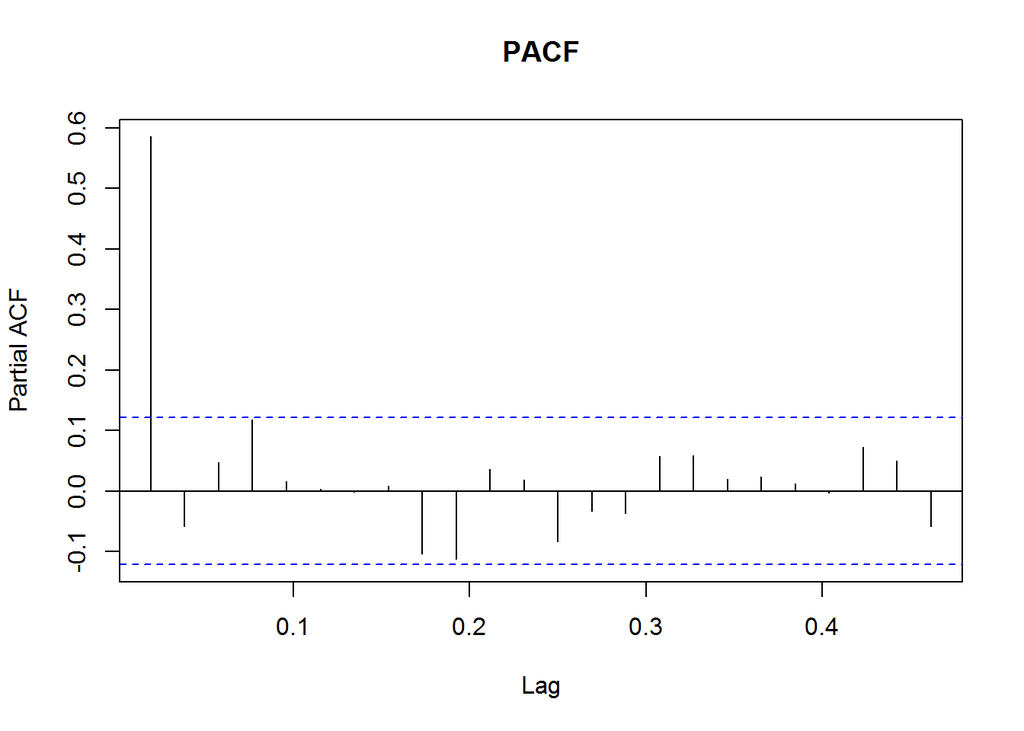

```r
pacf(dts, main = 'PACF')
```

В этих данных логично предполагать годовую сезонность, этому соотвествует близость PACF в точке 1 к пунктирной линии. Сезонный порядок модели выберем равным единице, а несезонный порядок равен 1, либо 4.

Исследуем обе модели. Построим прогнозы на 12 недель вперед, а также доверительные интервалы уровня 0.95.

**ARIMA(1,0,0)(1,0,0)[52]**

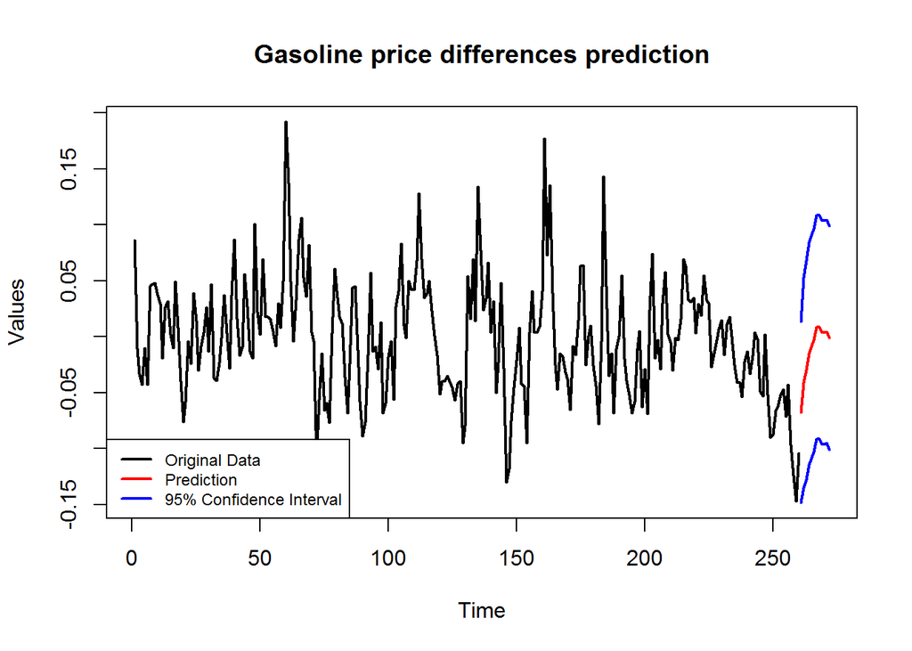

```r
FORECAST_RANGE <- 12

m1 <- arima(dts, order = c(1,0,0),
            seasonal = list(order = c(1,0,0), period = 52), method = 'ML')
f1 <- predict(m1, n.ahead = FORECAST_RANGE)
lci <- f1$pred - qnorm(0.025,0,1)*f1$se
uci <- f1$pred + qnorm(0.025,0,1)*f1$se

plot_diff1 <- data.frame(Original_data=c(dts, rep(NA, FORECAST_RANGE)),
                        Prediction = c(rep(NA, length(dts)), f1$pred),
                        Upper_CI = c(rep(NA, length(dts)), uci),
                        Lower_CI = c(rep(NA, length(dts)), lci))
matplot(plot_diff1, type = 'l', pch = 20, lty = 1,
        col = c('black', 'red', 'blue', 'blue'), lwd = 2,
        xlab = 'Time', ylab = 'Values',
        main = 'Gasoline price differences prediction')
legend('bottomleft', c('Original Data', 'Prediction', '95% Confidence Interval'),
       col = c('black', 'red', 'blue'), lwd = 2, cex = 0.75)
```

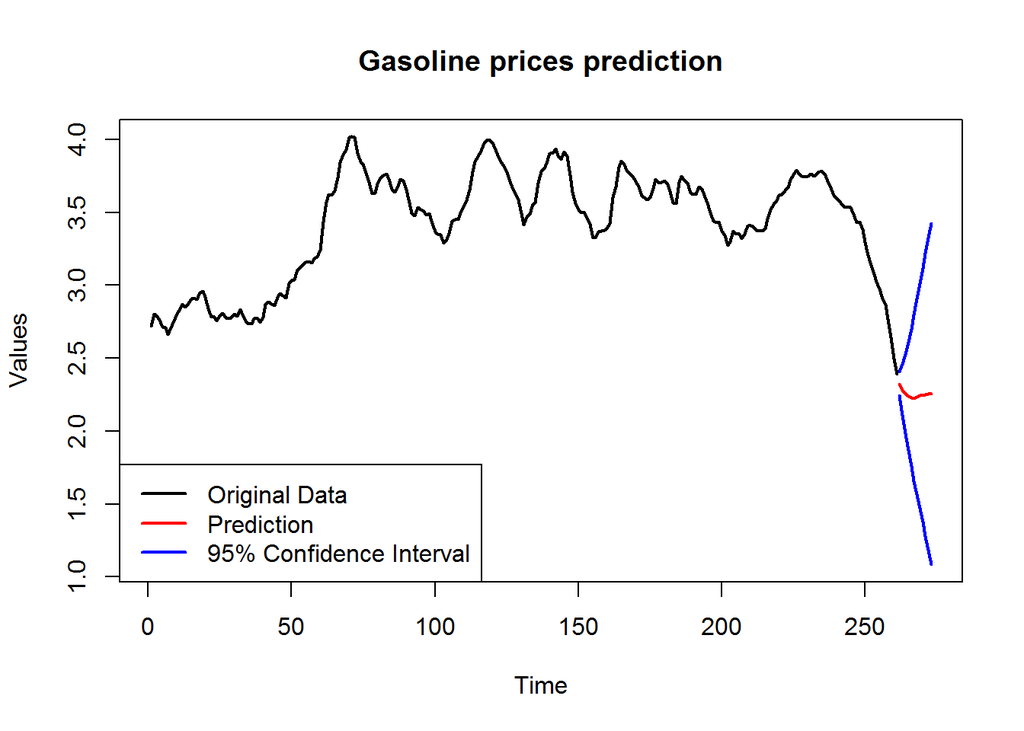

```r
first_value <- ts[1]
last_value <- ts[length(ts)]
plot_orig1 <- data.frame(Original_data = c(diffinv(dts, lag = 1, differences = 1, first_value),
                                           rep(NA, FORECAST_RANGE)),
                        Prediction = c(rep(NA, length(ts)),
                                       diffinv(f1$pred, lag = 1, differences = 1, last_value)[2:13]),
                        Upper_CI = c(rep(NA, length(ts)),
                                     diffinv(uci, lag = 1, differences = 1, last_value)[2:13]),
                        Lower_CI = c(rep(NA, length(ts)),
                                     diffinv(lci, lag = 1, differences = 1, last_value)[2:13]))
matplot(plot_orig1, type = 'l', pch = 20, lty = 1,
        col = c('black', 'red', 'blue', 'blue'),
        lwd = 2, xlab = 'Time', ylab = 'Values',
        main = 'Gasoline prices prediction')
legend('bottomleft', c('Original Data', 'Prediction', '95% Confidence Interval'),
       col = c('black', 'red', 'blue'), lwd = 2)
```

**ARIMA(4,0,0)(1,0,0)[52]**

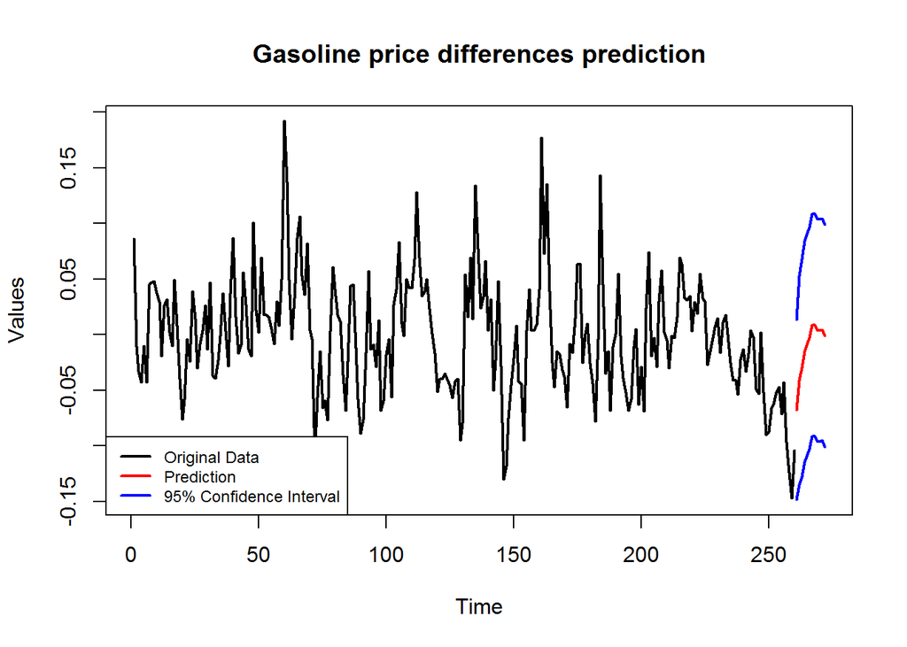

```r
m2 <- arima(dts, order = c(4,0,0),
            seasonal = list(order = c(1,0,0), period = 52), method = 'ML')
f2 <- predict(m1, n.ahead = FORECAST_RANGE)
lci <- f2$pred - qnorm(0.025,0,1)*f2$se
uci <- f2$pred + qnorm(0.025,0,1)*f2$se

plot_diff2 <- data.frame(Original_data=c(dts, rep(NA, FORECAST_RANGE)),
                        Prediction = c(rep(NA, length(dts)), f2$pred),
                        Upper_CI = c(rep(NA, length(dts)), uci),
                        Lower_CI = c(rep(NA, length(dts)), lci))
matplot(plot_diff2, type = 'l', pch = 20, lty = 1,
        col = c('black', 'red', 'blue', 'blue'),
        lwd = 2, xlab = 'Time', ylab = 'Values',
        main = 'Gasoline price differences prediction')
legend('bottomleft', c('Original Data', 'Prediction', '95% Confidence Interval'),
       col = c('black', 'red', 'blue'), lwd = 2, cex = 0.75)
```

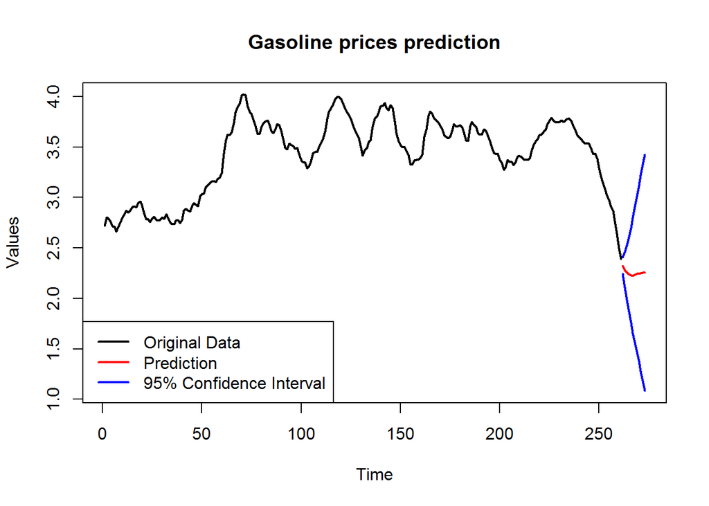

```r
first_value <- ts[1]
last_value <- ts[length(ts)]
plot_orig2 <- data.frame(Original_data = c(diffinv(dts, lag = 1, differences = 1, first_value),
                                           rep(NA, FORECAST_RANGE)),
                        Prediction = c(rep(NA, length(ts)),
                                       diffinv(f2$pred, lag = 1, differences = 1, last_value)[2:13]),
                        Upper_CI = c(rep(NA, length(ts)),
                                     diffinv(uci, lag = 1, differences = 1, last_value)[2:13]),
                        Lower_CI = c(rep(NA, length(ts)),
                                     diffinv(lci, lag = 1, differences = 1, last_value)[2:13]))
matplot(plot_orig1, type = 'l', pch = 20, lty = 1,
        col = c('black', 'red', 'blue', 'blue'),
        lwd = 2, xlab = 'Time', ylab = 'Values',
        main = 'Gasoline prices prediction')
legend('bottomleft', c('Original Data', 'Prediction', '95% Confidence Interval'),
       col = c('black', 'red', 'blue'), lwd = 2)
```

```r
c(AIC(m1), AIC(m2))
```

```
## [1] -908.9459 -906.6916
```

Первая модель предпочтительнее.

Исследуем остатки модели.

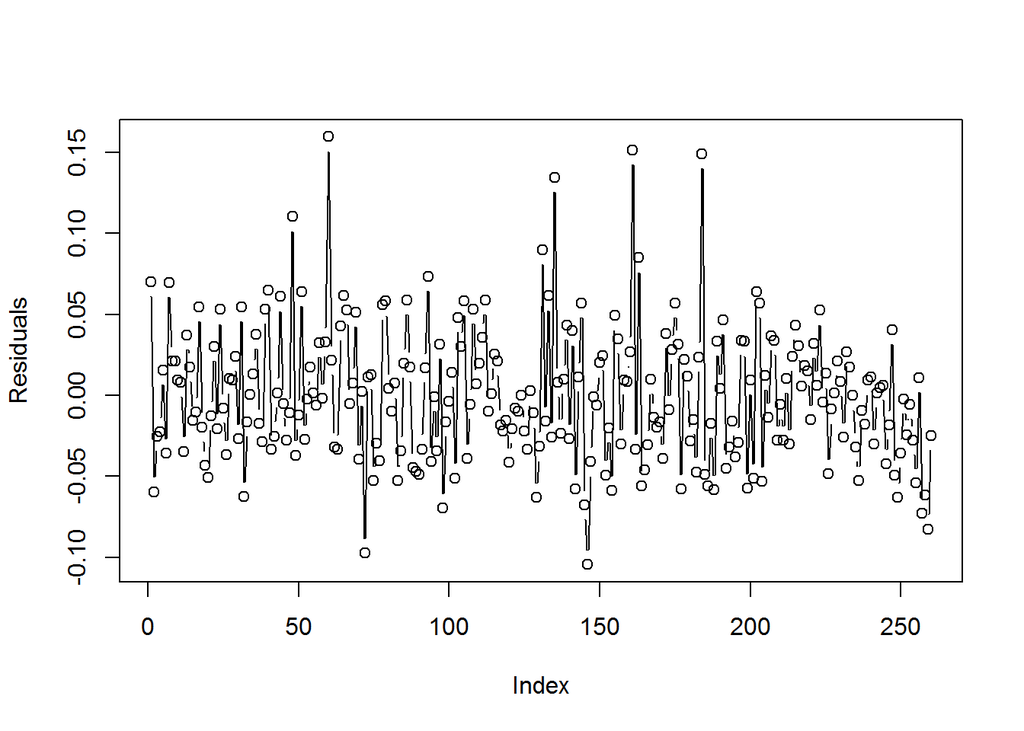

```r
res <- as.vector(m1$residuals)
plot(res, ylab = 'Residuals', type = 'b')
```

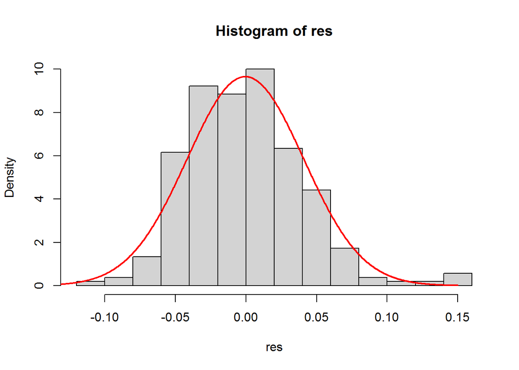

```r
hist(res, freq = FALSE)
x <- seq(-0.15, 0.15, length.out = 1000)
fd_norm <- fitdist(res, 'norm')
a <- fd_norm$estimate[1]
sigma <- fd_norm$estimate[2]
lines(x, 1/( sigma*sqrt(2*pi) )*exp( -0.5*( ( ( x-a )/sigma)^2 ) ),
      col='red', lwd = 2, type = 'l')
```

Видно, что распределение остатков близко к нормальному. Слегка мешает тяжелый хвост справа.

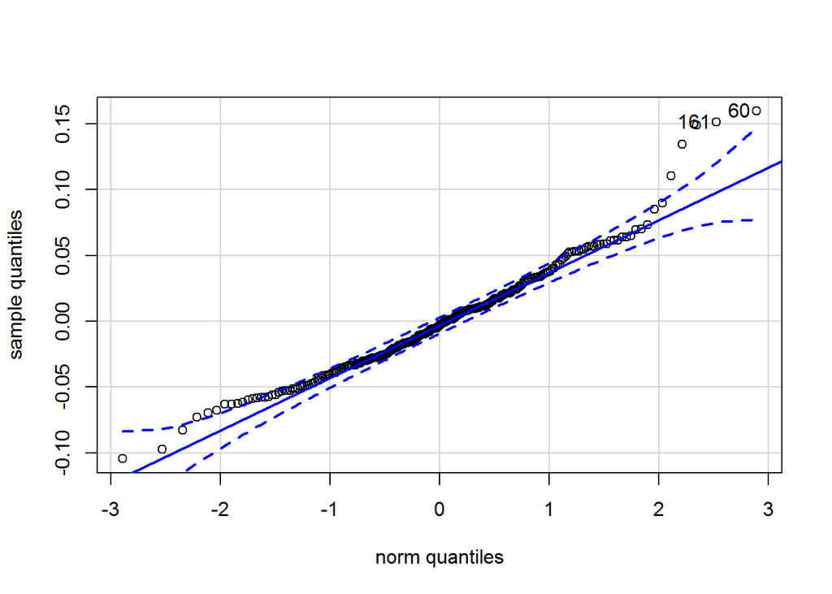

```r
qqPlot(res, ylab = 'sample quantiles')
```

Проведем тест Колмогорова-Смирнова на нормальность. Оценим параметры распределения по 70% наблюдений, а тест выполним на оставшихся 30%.

```r
RATIO <- 0.7
tr_index <- sample(1:length(res), length(res)*RATIO)
train_res <- res[tr_index]
test_res <- res[-tr_index]
fd_train <- fitdist(train_res, 'norm')
ks.test(test_res, 'pnorm', fd_train$estimate[1], fd_train$estimate[2])
```

```
##
##  One-sample Kolmogorov-Smirnov test
##
## data:  test_res
## D = 0.10694, p-value = 0.3118
## alternative hypothesis: two-sided
```

Тест Колмогорова-Смирнова не отвергает гипотезу о нормальности распределения остатков.

Посмотрим на ACF и PACF остатков.

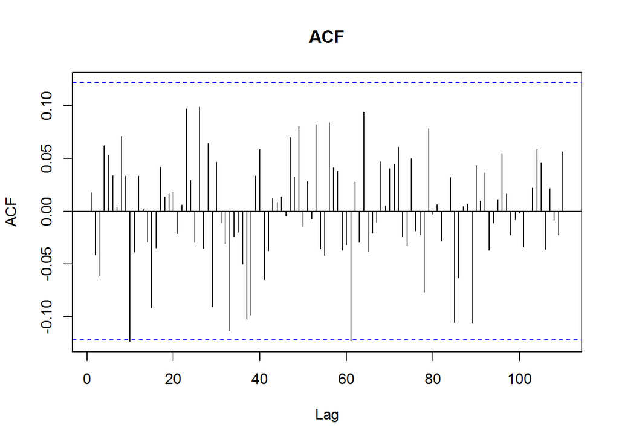

```r
acf(res, lag.max = 110, main = 'ACF')
```

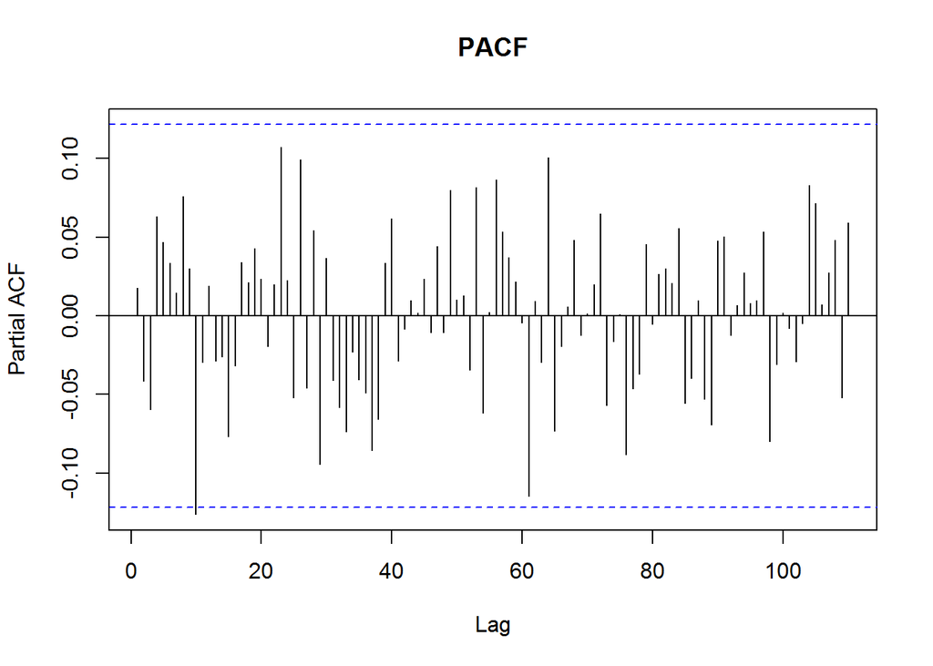

```r
pacf(res, lag.max = 110, main = 'PACF')
```

Почти все значения ACF и PACF не значимы, что свидетельствует об отсутствии автокорреляции в остатках.

```r
Box.test(res, lag = 52, type = 'Ljung-Box', fitdf = length(coef(m1)))
```

```
##
##  Box-Ljung test
##
## data:  res
## X-squared = 43.466, df = 49, p-value = 0.6962
```

Тест Льюнг-Бокса не отвергает гипотезу о случайности остатков.

Построим оценку спектральной плотности к начальным данным и к остаткам после удаления модели.

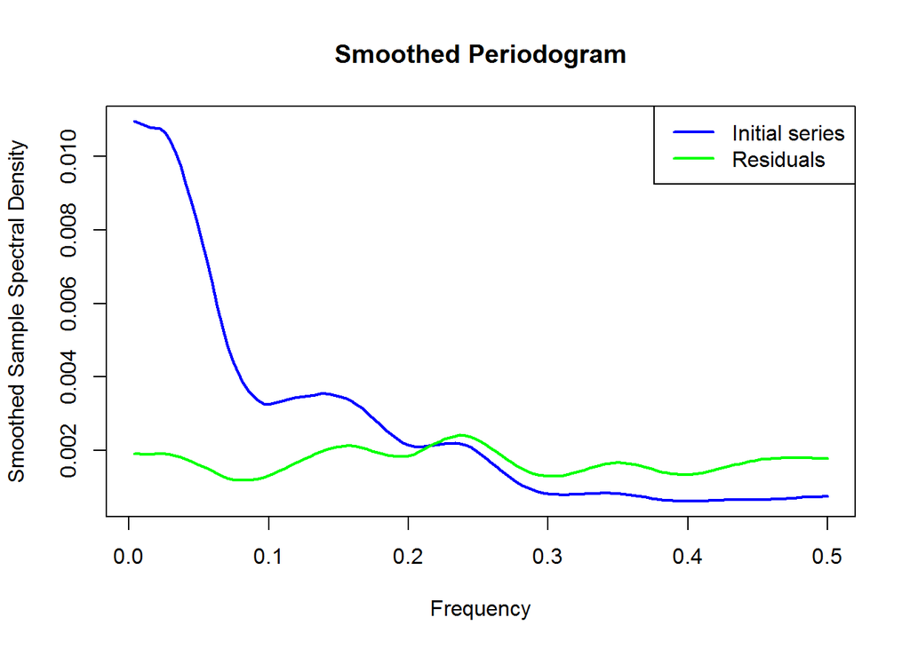

```r
k3 <- kernel('daniell', c(5,5,5))
s_res <- spec(res, kernel = k3, log = 'no', sub = '', plot = FALSE)
s <- spec(dts, kernel = k3, log = 'no', sub = '', col = 'blue', lwd = 2,
     xlab = 'Frequency', ylab = 'Smoothed Sample Spectral Density',
     main = 'Smoothed Periodogram', ylim=)
lines(s_res$freq, s_res$spec, col = 'green', lwd = 2)
legend('topright', c('Initial series', 'Residuals'), lwd = 2,
       col = c('blue', 'green'))
```

Остатки ближе к белому шуму, значит модель учла все основные закономерности в исходных данных.

В заключение построим прогноз по модели Хольта-Винтерса.

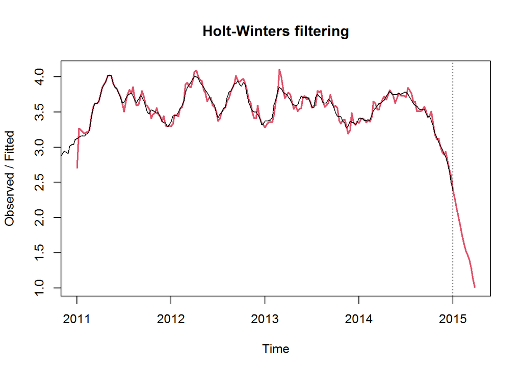

```r
m3 <- HoltWinters(ts, seasonal = 'multiplicative')
f3 <- predict(m3, n.ahead = 12)
plot(m3, predicted.values = f3, lwd = 2)
```

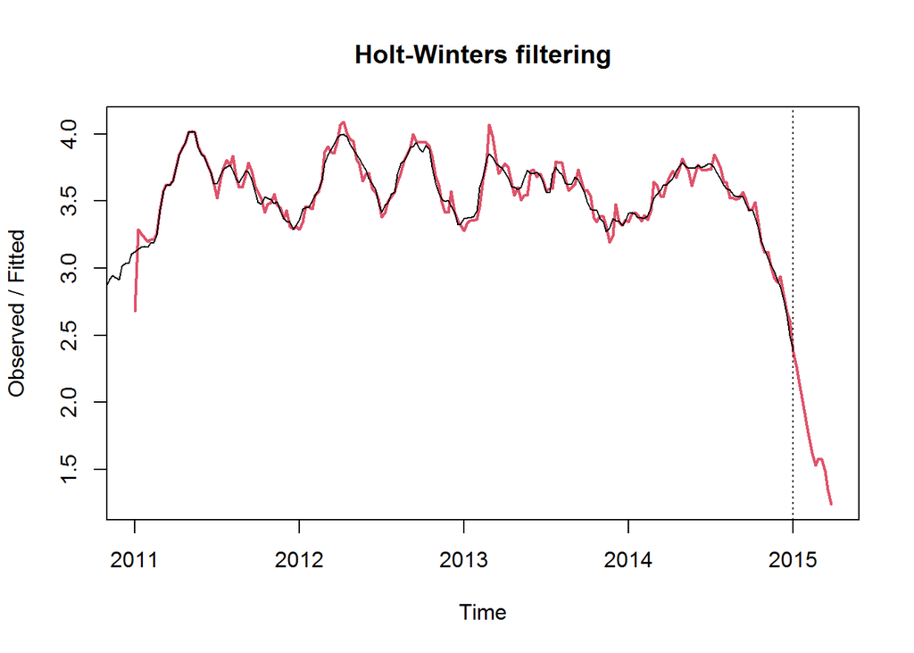

```r
m4 <- HoltWinters(ts, seasonal = 'additive')
f4 <- predict(m4, n.ahead = 12)
plot(m4, predicted.values = f4, lwd = 2)
```